# Final Project Notebook

## Final Project BIS 634

```python
import warnings
warnings.filterwarnings("ignore")
```

## Table of contents:

1. 1. Intro
2. 2. Dataset Desciption
3. 3. Data Analysis
4. 4. Feature Selection
5. 5. Model Training
6. 6. Model Evaluation with test set
7. 7. Explaining the model
8. 8. Flask Web App

## 1. Introduction

This notebook is the final project for BIS 634 omputational Methods for Informatics. This notebook an be broken down into data description, data analysis, training machine learning models, performing predictions and creating a webapp for the notebook.

## 2. Dataset Description

**Title:** [Smoking and Drinking Dataset with Body Signal](https://www.kaggle.com/datasets/sooyoungher/smoking-drinking-dataset)

**Introduction:** The dataset containing body signal data related to smoking and alcohol consumption is a valuable resource for predictive analysis. It originates from the National Health Insurance Service in Korea and has undergone meticulous curation to safeguard privacy and data security by excluding any personal or sensitive information

**Dataset Purpose:** The primary objectives of this dataset:

**Analysis of Body Signals:** The dataset contains a wide range of body signal measurements, incorporating diverse physiological and health-related characteristics. Researchers and data scientists can utilize this extensive dataset to explore the connections between these signals and the patterns of smoking and drinking behaviors, deriving valuable insights from the data.

**Classification of Smokers and Drinkers:** A prominent use case for this dataset involves categorizing individuals into two specific groups: smokers and drinkers. Through the utilization of machine learning and statistical methodologies, professionals can create predictive models capable of accurately determining if an individual belongs to either or both of these groups using their body signal data.

**Data Overview:** Within the Smoking and Drinking Dataset, a diverse set of parameters is present, incorporating factors like age, height, weight, blood pressure, cholesterol levels, among others. These parameters serve as fundamental components for comprehending the physiological traits within the dataset. Moreover, the dataset comprises details concerning smoking behaviors, alcohol consumption patterns, and a spectrum of body signal measurements.

```python
# Imports
import pandas as pd
import numpy as np
import seaborn as sns
import matplotlib.pyplot as plt

# Importing data
df = pd.read_csv("smoking_driking_dataset_Ver01.csv")
df.head()
```

|  | sex | age | height | weight | waistline | sight_left | sight_right | hear_left | hear_right | SBP | ... | LDL_chole | triglyceride | hemoglobin | urine_protein | serum_creatinine | SGOT_AST | SGOT_ALT | gamma_GTP | SMK_stat_type_cd | DRK_YN |
| --- | --- | --- | --- | --- | --- | --- | --- | --- | --- | --- | --- | --- | --- | --- | --- | --- | --- | --- | --- | --- | --- |
| 0 | Male | 35 | 170 | 75 | 90.0 | 1.0 | 1.0 | 1.0 | 1.0 | 120.0 | ... | 126.0 | 92.0 | 17.1 | 1.0 | 1.0 | 21.0 | 35.0 | 40.0 | 1.0 | Y |
| 1 | Male | 30 | 180 | 80 | 89.0 | 0.9 | 1.2 | 1.0 | 1.0 | 130.0 | ... | 148.0 | 121.0 | 15.8 | 1.0 | 0.9 | 20.0 | 36.0 | 27.0 | 3.0 | N |
| 2 | Male | 40 | 165 | 75 | 91.0 | 1.2 | 1.5 | 1.0 | 1.0 | 120.0 | ... | 74.0 | 104.0 | 15.8 | 1.0 | 0.9 | 47.0 | 32.0 | 68.0 | 1.0 | N |
| 3 | Male | 50 | 175 | 80 | 91.0 | 1.5 | 1.2 | 1.0 | 1.0 | 145.0 | ... | 104.0 | 106.0 | 17.6 | 1.0 | 1.1 | 29.0 | 34.0 | 18.0 | 1.0 | N |
| 4 | Male | 50 | 165 | 60 | 80.0 | 1.0 | 1.2 | 1.0 | 1.0 | 138.0 | ... | 117.0 | 104.0 | 13.8 | 1.0 | 0.8 | 19.0 | 12.0 | 25.0 | 1.0 | N |

5 rows × 24 columns

```python
df.describe().T
```

|  | count | mean | std | min | 25% | 50% | 75% | max |
| --- | --- | --- | --- | --- | --- | --- | --- | --- |
| age | 991346.0 | 47.614491 | 14.181339 | 20.0 | 35.0 | 45.0 | 60.0 | 85.0 |
| height | 991346.0 | 162.240625 | 9.282957 | 130.0 | 155.0 | 160.0 | 170.0 | 190.0 |
| weight | 991346.0 | 63.284050 | 12.514241 | 25.0 | 55.0 | 60.0 | 70.0 | 140.0 |
| waistline | 991346.0 | 81.233358 | 11.850323 | 8.0 | 74.1 | 81.0 | 87.8 | 999.0 |
| sight_left | 991346.0 | 0.980834 | 0.605949 | 0.1 | 0.7 | 1.0 | 1.2 | 9.9 |
| sight_right | 991346.0 | 0.978429 | 0.604774 | 0.1 | 0.7 | 1.0 | 1.2 | 9.9 |
| hear_left | 991346.0 | 1.031495 | 0.174650 | 1.0 | 1.0 | 1.0 | 1.0 | 2.0 |
| hear_right | 991346.0 | 1.030476 | 0.171892 | 1.0 | 1.0 | 1.0 | 1.0 | 2.0 |
| SBP | 991346.0 | 122.432498 | 14.543148 | 67.0 | 112.0 | 120.0 | 131.0 | 273.0 |
| DBP | 991346.0 | 76.052627 | 9.889365 | 32.0 | 70.0 | 76.0 | 82.0 | 185.0 |
| BLDS | 991346.0 | 100.424447 | 24.179960 | 25.0 | 88.0 | 96.0 | 105.0 | 852.0 |
| tot_chole | 991346.0 | 195.557020 | 38.660155 | 30.0 | 169.0 | 193.0 | 219.0 | 2344.0 |
| HDL_chole | 991346.0 | 56.936800 | 17.238479 | 1.0 | 46.0 | 55.0 | 66.0 | 8110.0 |
| LDL_chole | 991346.0 | 113.037692 | 35.842812 | 1.0 | 89.0 | 111.0 | 135.0 | 5119.0 |
| triglyceride | 991346.0 | 132.141751 | 102.196985 | 1.0 | 73.0 | 106.0 | 159.0 | 9490.0 |
| hemoglobin | 991346.0 | 14.229824 | 1.584929 | 1.0 | 13.2 | 14.3 | 15.4 | 25.0 |
| urine_protein | 991346.0 | 1.094224 | 0.437724 | 1.0 | 1.0 | 1.0 | 1.0 | 6.0 |
| serum_creatinine | 991346.0 | 0.860467 | 0.480530 | 0.1 | 0.7 | 0.8 | 1.0 | 98.0 |
| SGOT_AST | 991346.0 | 25.989308 | 23.493386 | 1.0 | 19.0 | 23.0 | 28.0 | 9999.0 |
| SGOT_ALT | 991346.0 | 25.755051 | 26.308599 | 1.0 | 15.0 | 20.0 | 29.0 | 7210.0 |
| gamma_GTP | 991346.0 | 37.136347 | 50.424153 | 1.0 | 16.0 | 23.0 | 39.0 | 999.0 |
| SMK_stat_type_cd | 991346.0 | 1.608122 | 0.818507 | 1.0 | 1.0 | 1.0 | 2.0 | 3.0 |

further data description:

| Column/Feature | Description |
| --- | --- |
| Sex | male, female |
| Age | round up to 5 years |
| Height | round up to 5 cm (cm) |
| Weight | (kg) |
| Sight_left | eyesight (left) |
| Sight_right | eyesight (right) |
| Hear_left | hearing left, 1 (normal), 2 (abnormal) |
| Hear_right | hearing right, 1 (normal), 2 (abnormal) |
| SBP | Systolic blood pressure (mmHg) |
| DBP | Diastolic blood pressure (mmHg) |
| BLDS | Blood Sugar Level or Fasting Blood Glucose (mg/dL) |
| Tot_chole | total cholesterol (mg/dL) |
| HDL_chole | High-Density Lipoprotein cholesterol (mg/dL) |
| LDL_chole | Low-Density Lipoprotein cholesterol (mg/dL) |
| Triglyceride | triglyceride (mg/dL) |
| Hemoglobin | hemoglobin (g/dL) |
| Urine_protein | protein in urine, 1 (-), 2 (+/-), 3 (+1), 4 (+2), 5 (+3), 6 (+4) |
| Serum_creatinine | serum (blood) creatinine (mg/dL) |
| SGOT_AST | Serum Glutamate Oxaloacetate Transaminase Aspartate Transaminase (IU/L) |
| SGOT_ALT | Serum Glutamate Oxaloacetate Transaminase Alanine Transaminase (IU/L) |
| Gamma_GTP | γ-Glutamyl Transpeptidase (IU/L) |
| SMK_stat_type_cd | Smoking state, 1 (never), 2 (used to smoke but quit), 3 (still smoke) |
| DRK_YN | Drinker or Not |

1. In the dataset, the "**Sex**" column denotes the gender of individuals, offering choices between "male" or "female."
2. The column "**Age**" presents the individuals' age, rounded up to the nearest 5 years.
3. "**Height**" refers to the height of individuals, rounded to the closest 5 centimeters (cm).
4. The column labeled "**Weight**" specifies the weight of individuals, measured in kilograms (kg).
5. **Sight_left** / **Sight_right**: These columns provide information about the left and right eyes' visual acuity or eyesight.
6. "**Hear_left**" and "**Hear_right**" indicate the condition of hearing in the left and right ears, respectively.
7. "**SBP**" stands for Systolic Blood Pressure, and "**DBP**" stands for Diastolic Blood Pressure, both measured in millimeters of mercury (mmHg). These values offer crucial cardiovascular health insights, aiding in hypertension diagnosis and cardiovascular risk assessment.
8. "**BLDS**" represents Blood Sugar Level or Fasting Blood Glucose, measured in milligrams per deciliter (mg/dL), vital for monitoring blood sugar control and diagnosing diabetes.
9. **Tot_chole** / **HDL_chole** / **LDL_chole** / Triglyceride: These columns present cholesterol-related measurements, including total cholesterol, High-Density Lipoprotein (HDL), Low-Density Lipoprotein (LDL), and triglyceride levels, essential for cardiovascular health assessment.
10. "**Hemoglobin**" indicates the blood's hemoglobin level, measured in grams per deciliter (g/dL), pivotal for assessing anemia and blood oxygenation.
11. "**Urine_protein**" signifies the presence of protein in urine, providing insights into kidney function and disease.
12. "**Serum_creatinine**" measures serum creatinine concentration, crucial for kidney function evaluation.
13. **SGOT_AST** / **SGOT_ALT** / **Gamma_GTP**: These columns contain enzyme measurements related to liver and metabolic health.
14. "**SMK_stat_type_cd**" illustrates the smoking status of individuals with codes representing different smoking behaviors.
15. "**DRK_YN**" indicates whether individuals are drinkers or non-drinkers.

```python
df.info()
```

```
<class 'pandas.core.frame.DataFrame'>
RangeIndex: 991346 entries, 0 to 991345
Data columns (total 24 columns):
 #   Column            Non-Null Count   Dtype
---  ------            --------------   -----
 0   sex               991346 non-null  object
 1   age               991346 non-null  int64
 2   height            991346 non-null  int64
 3   weight            991346 non-null  int64
 4   waistline         991346 non-null  float64
 5   sight_left        991346 non-null  float64
 6   sight_right       991346 non-null  float64
 7   hear_left         991346 non-null  float64
 8   hear_right        991346 non-null  float64
 9   SBP               991346 non-null  float64
```

[output cut: 16 more lines]

**Dataframe Shape:** The dataset contains 991346 rows (entries) and 24 columns

**Data Type:** Columns `sex` and `DRK_YN` are of the datatype object, `age`, `height` and `weight` are of the datatype int64. The remaining columns are all of the datatype float64, indicating that they contain numerical data with decimal points.

**Missing Values:** This dataset is complete.

## 3. Data Analysis

There are no null values, so moving on to finding outliers and dropping duplicates.

```python
df_with_duplicates = df.shape[0]
df =df.drop_duplicates()
df_without_duplicates = df.shape[0]

print(
    f"We dropped a total of {df_with_duplicates-df_without_duplicates} entries. \nTherefore we keep {(df_without_duplicates/df_with_duplicates)*100}% of our original data."
)
```

```
We dropped a total of 26 entries.
Therefore we keep 99.99737730318174% of our original data.
```

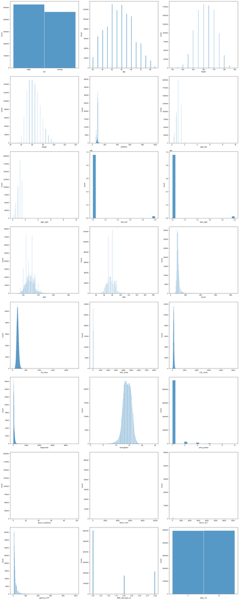

```python
import matplotlib.pyplot as plt
import seaborn as sns

# Define the DataFrame and other parameters
num_rows = 8
num_cols = 3

# Calculate the total number of plots
num_plots = min(len(df.columns), num_rows * num_cols)

# Create the subplots
fig, axes = plt.subplots(num_rows, num_cols, figsize=(20, 50))

# Flatten the axes for easy iteration
axes = axes.flatten()

# Set Seaborn style
sns.set(style="whitegrid")

# Loop to plot histograms for each column
for i, column in enumerate(df.columns[:num_plots]):
    sns.histplot(data=df, x=column, ax=axes[i])
    axes[i].set_xlabel(column)
    axes[i].set_ylabel("Count")

# Remove excess empty subplots
for i in range(num_plots, num_rows * num_cols):
    fig.delaxes(axes[i])

# Adjust layout and display the plot
plt.tight_layout()
plt.savefig("seaborn.png", dpi=200, bbox_inches='tight')

plt.show()
```

```python
# Record the initial number of entries in the DataFrame
df_with_outlier =df.shape[0]

# Define the columns to check for outliers
columns_to_check = [
    "age", "height", "weight", "waistline", "sight_left", "sight_right",
    "SBP", "DBP", "BLDS", "tot_chole", "HDL_chole", "LDL_chole", "triglyceride",
    "hemoglobin", "serum_creatinine", "SGOT_AST", "SGOT_ALT", "gamma_GTP"
]

# Calculate Z-scores for the specified columns
z_scores = (df[columns_to_check] - df[columns_to_check].mean()) / df[columns_to_check].std()

# Set the threshold for outlier detection (3σ standard deviation)
threshold = 3
outliers = np.abs(z_scores) > threshold
outlier_columns = outliers.columns[outliers.any()]

# Filter the DataFrame by removing rows containing outliers
df_cleaned = df[~outliers.any(axis=1)]

# Record the number of entries after outlier removal
df_without_outlier = df_cleaned.shape[0]

# Print the information about the change in the number of entries
print(
    f"Due to the removal of outliers, the number of entries reduced from {df_with_outlier} to {df_without_outlier} by {df_with_outlier - df_without_outlier} entries."
)
```

```
Due to the removal of outliers, the number of entries reduced from 991320 to 904029 by 87291 entries.
```

Performing the standard IQR for outlier removal deleted almost 1/3 rd of the dataset which is not ideal, hence z-score method was adopted for outlier removal.

##### Z-score-based outlier removal is advantageous for several reasons:

Standardization: Z-scores standardize data by measuring how many standard deviations a data point is from the mean. This normalization allows for fair comparisons between different datasets or variables with varying scales and distributions.

Identifying Magnitude of Deviation: Z-scores provide a clear indication of the magnitude of deviation from the mean. Higher absolute Z-scores signify more significant deviations, aiding in the identification of extreme values.

Threshold Setting: Z-scores offer a straightforward way to set a threshold (e.g., ±3 standard deviations) to identify outliers. This threshold captures extreme values that are relatively rare in a normal distribution.

Applicability to Different Distributions: Z-scores are versatile and applicable to various data distributions, including normal and non-normal distributions. This method can detect outliers in different distribution shapes without relying on assumptions about the data's underlying distribution.

Multivariate Analysis: Z-scores facilitate the identification of outliers across multiple variables simultaneously. This capability is valuable in multivariate analyses where relationships between several variables need consideration.

Interpretability: Z-scores are intuitive and easy to interpret. A Z-score of +2, for instance, signifies a value two standard deviations above the mean, indicating an extreme value in the dataset.

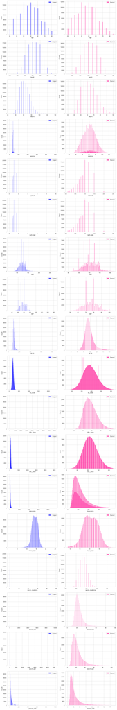

```python
import matplotlib.pyplot as plt
import seaborn as sns

columns_to_check = [
    "age", "height", "weight", "waistline", "sight_left", "sight_right",
    "SBP", "DBP", "BLDS", "tot_chole", "HDL_chole", "LDL_chole",
    "triglyceride", "hemoglobin", "serum_creatinine", "SGOT_AST",
    "SGOT_ALT", "gamma_GTP"
]

sns.set(style="whitegrid")

num_rows = len(columns_to_check)
fig, axes = plt.subplots(num_rows, 2, figsize=(15, 5 * num_rows))

for i, column in enumerate(columns_to_check):
    sns.histplot(data=df, x=column, ax=axes[i, 0], label="Original", color="blue")
    axes[i, 0].set_xlabel(column)
    axes[i, 0].set_ylabel("Count")

    sns.histplot(
        data=df_cleaned, x=column, ax=axes[i, 1],
        label="Cleaned", color="#FF1493"  # Hex code for a dark pink color
    )
    axes[i, 1].set_xlabel(column)
    axes[i, 1].set_ylabel("Count")

    axes[i, 0].legend(loc="upper right")
    axes[i, 1].legend(loc="upper right")

plt.tight_layout()
plt.savefig("compare(organdnew).png", dpi=200, bbox_inches='tight')
plt.show()
```

Upon examining the histograms presented earlier, it's apparent that the process of identifying and eliminating outliers has yielded successful outcomes. The histograms now display a more coherent distribution, allowing for better visualization compared to their initial representations. However, specific histograms like those for 'DBP' and 'SBP' exhibit peculiar patterns with multiple peaks. These distinct peaks seem to arise from potential rounding effects, appearing consistently at intervals that align with integer values of 10 (f(x) = 10*n, where n represents a natural number).

On analysing the dataset it is observed that there are three type of columns nominal, ordinal and metric columns. The ordinal column has ['hear_left', 'hear_right', 'urine_protein', 'SMK_stat_type_cd'], the Nomial columns are ['sex', 'DRK_YN'] and theh remaining columns are metric columns

### Data Analysis for the numerical columns

These visualizations generate a grid displaying histograms along with overlaid Kernel Density Estimates (KDEs). They aim to compare the distribution of several metric variables between two distinct categories: individuals categorized as drinkers and those classified as non-drinkers. This approach assists in evaluating potential distinctions or patterns within these variables across the two groups.

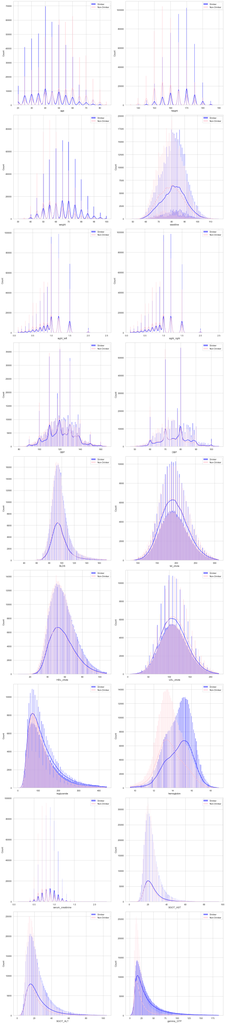

```python
num_rows = 9
num_cols = 2

columns_to_check = [
    "age", "height", "weight", "waistline", "sight_left", "sight_right",
    "SBP", "DBP", "BLDS", "tot_chole", "HDL_chole", "LDL_chole",
    "triglyceride", "hemoglobin", "serum_creatinine", "SGOT_AST",
    "SGOT_ALT", "gamma_GTP"
]

num_plots = min(len(columns_to_check), num_rows * num_cols)

fig, axes = plt.subplots(num_rows, num_cols, figsize=(16, 72))

axes = axes.flatten()

sns.set(style="whitegrid")

for i in range(num_plots):
    column = columns_to_check[i]

    drinkers = df_cleaned[df_cleaned["DRK_YN"] == "Y"]
    non_drinkers = df_cleaned[df_cleaned["DRK_YN"] == "N"]

    sns.histplot(drinkers[column], ax=axes[i], label="Drinker", kde=True, color="blue")
    sns.histplot(non_drinkers[column], ax=axes[i], label="Non-Drinker", kde=True, color='pink')

    axes[i].set_xlabel(column)
    axes[i].set_ylabel("Count")
    axes[i].legend()

for i in range(num_plots, num_rows * num_cols):
    fig.delaxes(axes[i])

plt.tight_layout()
plt.savefig("Kdeplot.png", dpi=200, bbox_inches='tight')
plt.show()
```

### Insights Gathered:

1. Patterns within certain metrics like age, height, and weight seem influenced by apparent rounding to the nearest 5 units. A notable trend indicates higher alcohol consumption among younger to middle-aged individuals compared to older ones. This observation invites exploration into whether societal shifts or generational aspects impact drinking tendencies.
2. Another intriguing observation links physical attributes and alcohol intake. Taller and heavier individuals tend to exhibit higher alcohol consumption, hinting at a potential gender influence, as men generally have greater height and weight averages compared to women, potentially impacting drinking habits.
3. While less pronounced, the waistline metric reflects a similar pattern, associating larger waistlines with increased alcohol consumption.
4. Metrics like BLDS, tot_chole, and HDL_chole show parallels between drinkers and non-drinkers. However, there's a subtle contrast with LDL_cholesterol, slightly higher among non-drinkers. This discrepancy suggests that alcohol might affect different cholesterol components uniquely.
5. Elevated triglyceride levels among drinkers suggest a plausible connection between alcohol intake and changes in lipid metabolism.
6. Hemoglobin levels reveal a dual-peak distribution. Given its association with males, this finding supports the hypothesis linking gender dynamics with drinking habits.
7. Metrics SGOT_ALT and gamma_GTP display higher values among alcohol consumers, hinting at potential liver function implications. These results prompt further investigation into alcohol's hepatotoxic effects.

### Data analysis for ordinal variables

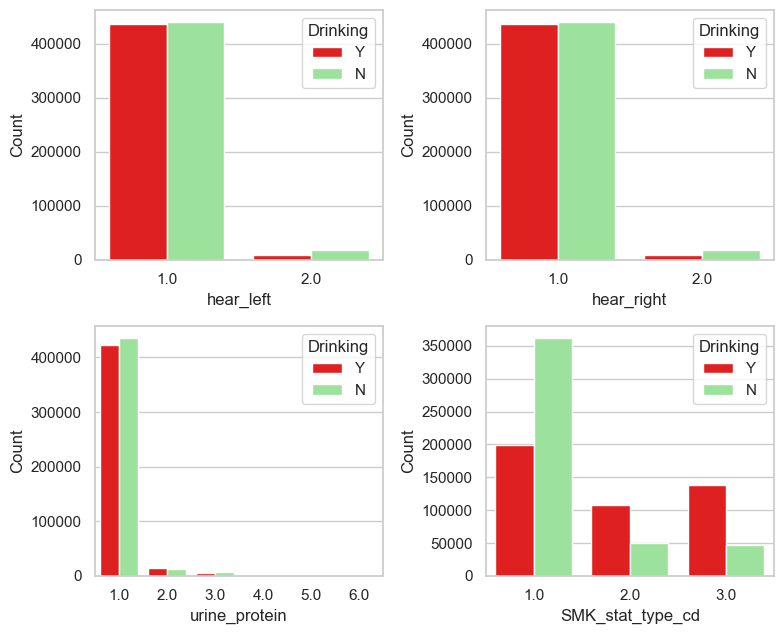

```python
fig, axes = plt.subplots(2, 2, figsize=(8, 6.5))
plt.subplots_adjust(hspace=0.5)

sns.set(style="whitegrid")

sns.countplot(data=df_cleaned, x="hear_left", hue="DRK_YN", ax=axes[0, 0], palette=["red", "lightgreen"])
axes[0, 0].set_xlabel("hear_left")
axes[0, 0].set_ylabel("Count")
axes[0, 0].legend(title="Drinking")

sns.countplot(data=df_cleaned, x="hear_right", hue="DRK_YN", ax=axes[0, 1], palette=["red", "lightgreen"])
axes[0, 1].set_xlabel("hear_right")
axes[0, 1].set_ylabel("Count")
axes[0, 1].legend(title="Drinking")

sns.countplot(data=df_cleaned, x="urine_protein", hue="DRK_YN", ax=axes[1, 0], palette=["red", "lightgreen"])
axes[1, 0].set_xlabel("urine_protein")
axes[1, 0].set_ylabel("Count")
axes[1, 0].legend(title="Drinking")

sns.countplot(data=df_cleaned, x="SMK_stat_type_cd", hue="DRK_YN", ax=axes[1, 1], palette=["red", "lightgreen"])
axes[1, 1].set_xlabel("SMK_stat_type_cd")
axes[1, 1].set_ylabel("Count")
axes[1, 1].legend(title="Drinking")

plt.tight_layout()
plt.savefig("ordinalplot.png", dpi=200, bbox_inches='tight')
plt.show()
```

### Data analysis fo the nominal variable

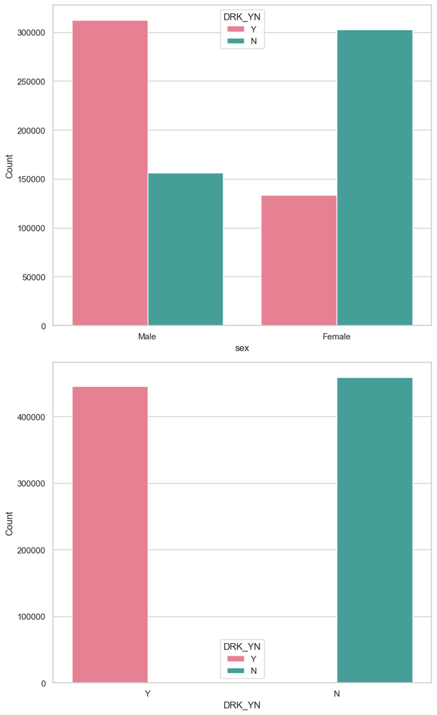

```python
columns_to_check = [ "sex", "DRK_YN"]
num_rows = len(columns_to_check)
num_cols = 1

fig, axes = plt.subplots(num_rows, num_cols, figsize=(8, 6.5 * num_rows))
plt.subplots_adjust(hspace=0.5)

sns.set(style="whitegrid")

for i, column in enumerate(columns_to_check):
    sns.countplot(data=df_cleaned, x=column, hue="DRK_YN", ax=axes[i], palette="husl")

    axes[i].set_xlabel(column)
    axes[i].set_ylabel("Count")

plt.tight_layout()
plt.savefig("Nominalvariable.png", dpi=200, bbox_inches='tight')
plt.show()
```

```python
df_cleaned
```

|  | sex | age | height | weight | waistline | sight_left | sight_right | hear_left | hear_right | SBP | ... | LDL_chole | triglyceride | hemoglobin | urine_protein | serum_creatinine | SGOT_AST | SGOT_ALT | gamma_GTP | SMK_stat_type_cd | DRK_YN |
| --- | --- | --- | --- | --- | --- | --- | --- | --- | --- | --- | --- | --- | --- | --- | --- | --- | --- | --- | --- | --- | --- |
| 0 | Male | 35 | 170 | 75 | 90.0 | 1.0 | 1.0 | 1.0 | 1.0 | 120.0 | ... | 126.0 | 92.0 | 17.1 | 1.0 | 1.0 | 21.0 | 35.0 | 40.0 | 1.0 | Y |
| 1 | Male | 30 | 180 | 80 | 89.0 | 0.9 | 1.2 | 1.0 | 1.0 | 130.0 | ... | 148.0 | 121.0 | 15.8 | 1.0 | 0.9 | 20.0 | 36.0 | 27.0 | 3.0 | N |
| 2 | Male | 40 | 165 | 75 | 91.0 | 1.2 | 1.5 | 1.0 | 1.0 | 120.0 | ... | 74.0 | 104.0 | 15.8 | 1.0 | 0.9 | 47.0 | 32.0 | 68.0 | 1.0 | N |
| 3 | Male | 50 | 175 | 80 | 91.0 | 1.5 | 1.2 | 1.0 | 1.0 | 145.0 | ... | 104.0 | 106.0 | 17.6 | 1.0 | 1.1 | 29.0 | 34.0 | 18.0 | 1.0 | N |
| 4 | Male | 50 | 165 | 60 | 80.0 | 1.0 | 1.2 | 1.0 | 1.0 | 138.0 | ... | 117.0 | 104.0 | 13.8 | 1.0 | 0.8 | 19.0 | 12.0 | 25.0 | 1.0 | N |
| ... | ... | ... | ... | ... | ... | ... | ... | ... | ... | ... | ... | ... | ... | ... | ... | ... | ... | ... | ... | ... | ... |
| 991341 | Male | 45 | 175 | 80 | 92.1 | 1.5 | 1.5 | 1.0 | 1.0 | 114.0 | ... | 125.0 | 132.0 | 15.0 | 1.0 | 1.0 | 26.0 | 36.0 | 27.0 | 1.0 | N |
| 991342 | Male | 35 | 170 | 75 | 86.0 | 1.0 | 1.5 | 1.0 | 1.0 | 119.0 | ... | 84.0 | 45.0 | 15.8 | 1.0 | 1.1 | 14.0 | 17.0 | 15.0 | 1.0 | N |
| 991343 | Female | 40 | 155 | 50 | 68.0 | 1.0 | 0.7 | 1.0 | 1.0 | 110.0 | ... | 77.0 | 157.0 | 14.3 | 1.0 | 0.8 | 30.0 | 27.0 | 17.0 | 3.0 | Y |
| 991344 | Male | 25 | 175 | 60 | 72.0 | 1.5 | 1.0 | 1.0 | 1.0 | 119.0 | ... | 73.0 | 53.0 | 14.5 | 1.0 | 0.8 | 21.0 | 14.0 | 17.0 | 1.0 | N |
| 991345 | Male | 50 | 160 | 70 | 90.5 | 1.0 | 1.5 | 1.0 | 1.0 | 133.0 | ... | 153.0 | 163.0 | 15.8 | 1.0 | 0.9 | 24.0 | 43.0 | 36.0 | 3.0 | Y |

904029 rows × 24 columns

```python
female_count = df_cleaned[df_cleaned["sex"] == "Female"]["sex"].count()

male_count=df_cleaned[df_cleaned["sex"]=="Male"]["sex"].count()
```

```python
male_count
```

```
468341
```

```python
female_count
```

```
435688
```

#### Observations:

1. Male participants displayed a more than two-fold increase in alcohol consumption compared to their female counterparts. This significant gender disparity necessitates further investigation into potential sociocultural, behavioral, or physiological factors contributing to this observed difference.
2. The present study population showcases a commendable near-equal distribution of male and female participants. This balanced representation mitigates gender-related sampling biases, enhancing the robustness and reliability of the analyses and conclusions drawn from the data.

## 4. Feature Engineering

This section discusses: label encoding, standardization and feature selection

#### Label Encoding

Label encoding is necessary when dealing with categorical data in machine learning models because these models typically work with numerical data. By converting categorical variables like 'sex' and 'DRK_YN' into numerical format, it allows the machine learning algorithms to process and understand these features, enhancing their ability to make predictions or classifications based on the data.

```python
from sklearn.preprocessing import LabelEncoder

# Copy the DataFrame to avoid
# modifying the original data
encoded_df = df_cleaned.copy()

# Initialize the LabelEncoder
label_encoder = LabelEncoder()

# Encode 'sex' column where "Male":1 and "Female":0
encoded_df['sex'] = label_encoder.fit_transform(encoded_df['sex'])

# Encode 'DRK_YN' column where "Yes":1 and "No":0
encoded_df['DRK_YN'] = label_encoder.fit_transform(encoded_df['DRK_YN'])

# Display the modified DataFrame
encoded_df.head()
```

|  | sex | age | height | weight | waistline | sight_left | sight_right | hear_left | hear_right | SBP | ... | LDL_chole | triglyceride | hemoglobin | urine_protein | serum_creatinine | SGOT_AST | SGOT_ALT | gamma_GTP | SMK_stat_type_cd | DRK_YN |
| --- | --- | --- | --- | --- | --- | --- | --- | --- | --- | --- | --- | --- | --- | --- | --- | --- | --- | --- | --- | --- | --- |
| 0 | 1 | 35 | 170 | 75 | 90.0 | 1.0 | 1.0 | 1.0 | 1.0 | 120.0 | ... | 126.0 | 92.0 | 17.1 | 1.0 | 1.0 | 21.0 | 35.0 | 40.0 | 1.0 | 1 |
| 1 | 1 | 30 | 180 | 80 | 89.0 | 0.9 | 1.2 | 1.0 | 1.0 | 130.0 | ... | 148.0 | 121.0 | 15.8 | 1.0 | 0.9 | 20.0 | 36.0 | 27.0 | 3.0 | 0 |
| 2 | 1 | 40 | 165 | 75 | 91.0 | 1.2 | 1.5 | 1.0 | 1.0 | 120.0 | ... | 74.0 | 104.0 | 15.8 | 1.0 | 0.9 | 47.0 | 32.0 | 68.0 | 1.0 | 0 |
| 3 | 1 | 50 | 175 | 80 | 91.0 | 1.5 | 1.2 | 1.0 | 1.0 | 145.0 | ... | 104.0 | 106.0 | 17.6 | 1.0 | 1.1 | 29.0 | 34.0 | 18.0 | 1.0 | 0 |
| 4 | 1 | 50 | 165 | 60 | 80.0 | 1.0 | 1.2 | 1.0 | 1.0 | 138.0 | ... | 117.0 | 104.0 | 13.8 | 1.0 | 0.8 | 19.0 | 12.0 | 25.0 | 1.0 | 0 |

5 rows × 24 columns

#### Correlation matrix and correlation coefficient

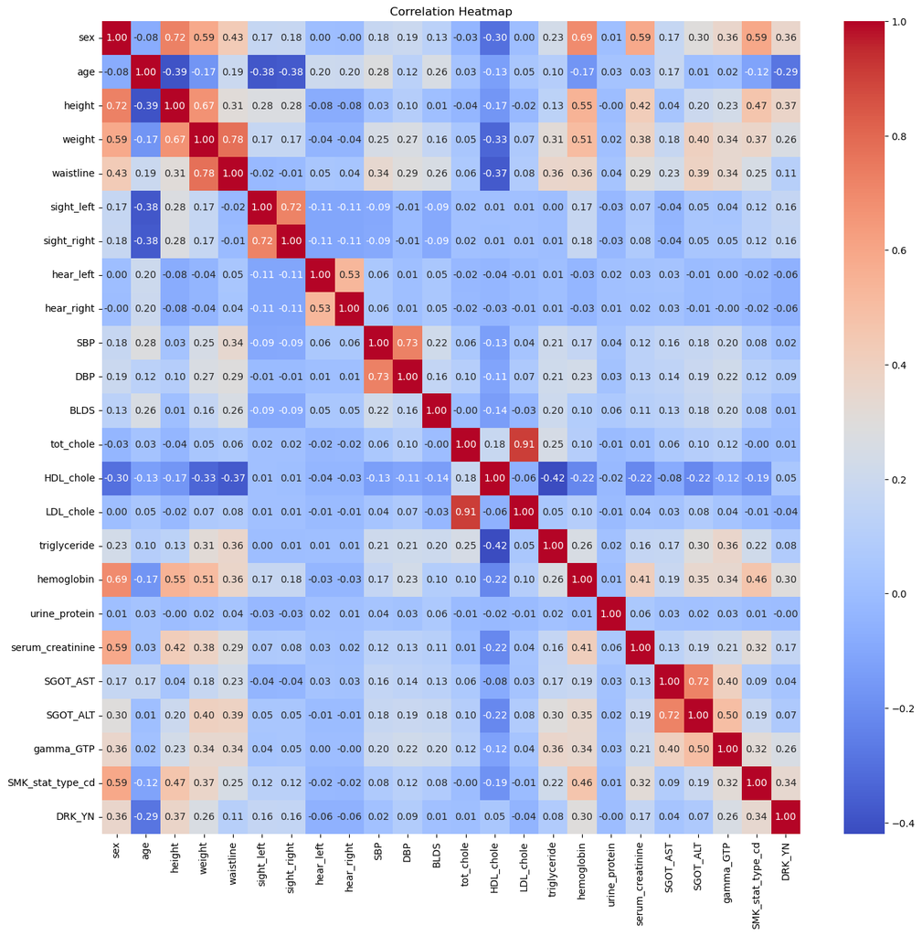

```python
import seaborn as sns
import matplotlib.pyplot as plt

# Compute the correlation matrix
corr_matrix = encoded_df.corr()

# Set up the matplotlib figure
plt.figure(figsize=(16, 15))

# Create a heatmap
sns.heatmap(corr_matrix, annot=True, cmap='coolwarm', fmt='.2f')

plt.title('Correlation Heatmap')
plt.savefig("corrplot.png", dpi=200, bbox_inches='tight')
plt.show()
```

```python
# Compute the correlation matrix including all columns
corr_matrix = encoded_df.corr()

# Set a threshold for correlation (e.g., 0.55)
threshold = 0.6

# Get pairs of highly correlated features
high_corr_features = np.where((abs(corr_matrix) > threshold) & (corr_matrix != 1))
high_corr_features = [(corr_matrix.columns[x], corr_matrix.columns[y], corr_matrix.iloc[x, y])
                      for x, y in zip(*high_corr_features) if x != y]

# Display correlated features and their correlation scores
for feat1, feat2, score in high_corr_features:
    print(f"Features: {feat1}, {feat2} have a correlation score of {score}")
```

```
Features: sex, height have a correlation score of 0.7230360727290859
Features: sex, hemoglobin have a correlation score of 0.6906007146011061
Features: height, sex have a correlation score of 0.7230360727290859
Features: height, weight have a correlation score of 0.6673273484343335
Features: weight, height have a correlation score of 0.6673273484343335
Features: weight, waistline have a correlation score of 0.7773568855077388
Features: waistline, weight have a correlation score of 0.7773568855077388
Features: sight_left, sight_right have a correlation score of 0.7212214733527972
Features: sight_right, sight_left have a correlation score of 0.7212214733527972
Features: SBP, DBP have a correlation score of 0.7254738117594569
Features: DBP, SBP have a correlation score of 0.7254738117594569
Features: tot_chole, LDL_chole have a correlation score of 0.907403944576826
Features: LDL_chole, tot_chole have a correlation score of 0.907403944576826
Features: hemoglobin, sex have a correlation score of 0.6906007146011061
Features: SGOT_AST, SGOT_ALT have a correlation score of 0.7223116309299994
Features: SGOT_ALT, SGOT_AST have a correlation score of 0.7223116309299994
```

```python
# removeing all columns that are collinear and highy correlated among themselves
columns_to_drop = ['sex','height', 'waistline','LDL_chole','SGOT_AST']  # Replace with your column names

# Dropping the specified columns
encoded_df.drop(columns=columns_to_drop, inplace=True)
```

#### Feature importance with random forest

```python
# Separate features (X) and target variable (y)
X = encoded_df.drop(columns=['DRK_YN'])
y = encoded_df['DRK_YN']
```

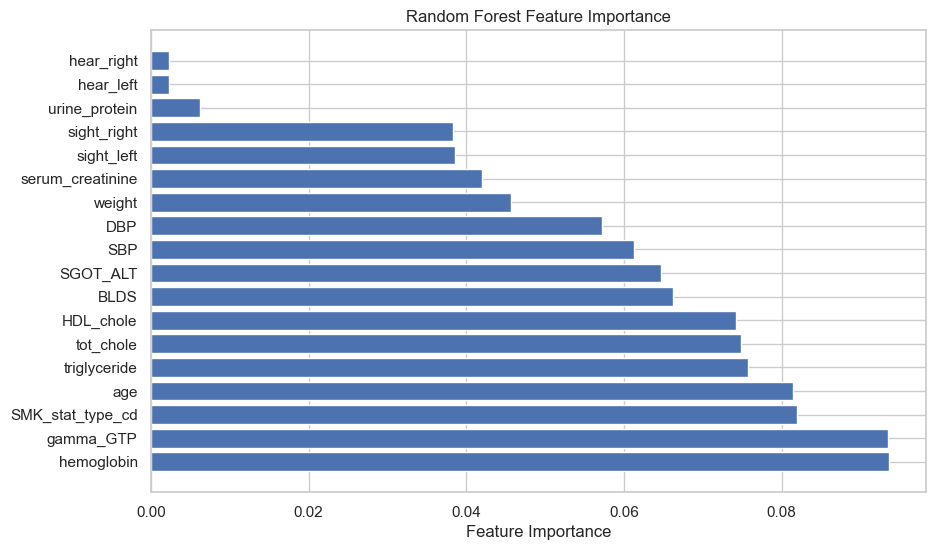

```python
from sklearn.ensemble import RandomForestClassifier
import matplotlib.pyplot as plt


# Create a Random Forest classifier
model = RandomForestClassifier()

# Fit the model to your data
model.fit(X, y)

# Get feature importances
importance_scores = model.feature_importances_

# Sort feature importance scores and get corresponding feature names
sorted_indices = importance_scores.argsort()[::-1]
feature_names = X.columns[sorted_indices]

# Plot feature importance
plt.figure(figsize=(10, 6))
plt.barh(range(X.shape[1]), importance_scores[sorted_indices], align='center')
plt.yticks(range(X.shape[1]), feature_names)
plt.xlabel('Feature Importance')
plt.title('Random Forest Feature Importance')
plt.savefig("randomforest.png", dpi=200, bbox_inches='tight')
plt.show()
```

```python
encoded_df.info()
```

```
<class 'pandas.core.frame.DataFrame'>
Int64Index: 904029 entries, 0 to 991345
Data columns (total 19 columns):
 #   Column            Non-Null Count   Dtype
---  ------            --------------   -----
 0   age               904029 non-null  int64
 1   weight            904029 non-null  int64
 2   sight_left        904029 non-null  float64
 3   sight_right       904029 non-null  float64
 4   hear_left         904029 non-null  float64
 5   hear_right        904029 non-null  float64
 6   SBP               904029 non-null  float64
 7   DBP               904029 non-null  float64
 8   BLDS              904029 non-null  float64
 9   tot_chole         904029 non-null  float64
 10  HDL_chole         904029 non-null  float64
 11  triglyceride      904029 non-null  float64
 12  hemoglobin        904029 non-null  float64
 13  urine_protein     904029 non-null  float64
 14  serum_creatinine  904029 non-null  float64
 15  SGOT_ALT          904029 non-null  float64
 16  gamma_GTP         904029 non-null  float64
 17  SMK_stat_type_cd  904029 non-null  float64
 18  DRK_YN            904029 non-null  int32
dtypes: float64(16), int32(1), int64(2)
memory usage: 134.5 MB
```

```python
encoded_df = encoded_df[['SMK_stat_type_cd', 'hemoglobin','age','gamma_GTP','SGOT_ALT','tot_chole','HDL_chole','BLDS','DBP','SBP','triglyceride','DRK_YN']]
```

```python
# Separate features (X) and target variable (y)
X = encoded_df.drop(columns=['DRK_YN'])
y = encoded_df['DRK_YN']
```

## 5. Model Training

#### Feature selection (Manually)

```python
from sklearn.model_selection import train_test_split
from sklearn.preprocessing import StandardScaler

# Split the data into train and test sets (80% train, 20% test)
X_train, X_test, y_train, y_test = train_test_split(X, y, test_size=0.2, random_state=42)

# Further split the train set into train and validation sets (60% train, 20% validation)
X_train, X_val, y_train, y_val = train_test_split(X_train, y_train, test_size=0.25, random_state=42)

# Initialize the StandardScaler
scaler = StandardScaler()

# Fit the scaler on the training data and transform all the sets
X_train_scaled = scaler.fit_transform(X_train)
X_test_scaled = scaler.transform(X_test)
X_val_scaled = scaler.transform(X_val)

# Convert scaled arrays back to DataFrames if needed
X_train_scaled_df = pd.DataFrame(X_train_scaled, columns=X.columns)
X_test_scaled_df = pd.DataFrame(X_test_scaled, columns=X.columns)
X_val_scaled_df = pd.DataFrame(X_val_scaled, columns=X.columns)
```

```python
X_train
```

|  | SMK_stat_type_cd | hemoglobin | age | gamma_GTP | SGOT_ALT | tot_chole | HDL_chole | BLDS | DBP | SBP | triglyceride |
| --- | --- | --- | --- | --- | --- | --- | --- | --- | --- | --- | --- |
| 537959 | 1.0 | 13.0 | 55 | 86.0 | 30.0 | 225.0 | 58.0 | 125.0 | 60.0 | 100.0 | 91.0 |
| 876525 | 2.0 | 15.0 | 50 | 43.0 | 20.0 | 194.0 | 52.0 | 99.0 | 90.0 | 150.0 | 121.0 |
| 342805 | 3.0 | 15.3 | 30 | 42.0 | 55.0 | 218.0 | 50.0 | 101.0 | 80.0 | 132.0 | 120.0 |
| 458991 | 3.0 | 16.9 | 60 | 37.0 | 18.0 | 222.0 | 42.0 | 104.0 | 88.0 | 138.0 | 126.0 |
| 78123 | 1.0 | 14.6 | 50 | 39.0 | 17.0 | 179.0 | 87.0 | 89.0 | 65.0 | 111.0 | 68.0 |
| ... | ... | ... | ... | ... | ... | ... | ... | ... | ... | ... | ... |
| 349831 | 1.0 | 10.2 | 40 | 16.0 | 14.0 | 196.0 | 68.0 | 98.0 | 65.0 | 119.0 | 60.0 |
| 668826 | 1.0 | 13.0 | 35 | 22.0 | 11.0 | 186.0 | 72.0 | 84.0 | 60.0 | 100.0 | 52.0 |
| 339956 | 2.0 | 15.5 | 40 | 18.0 | 23.0 | 203.0 | 53.0 | 91.0 | 88.0 | 130.0 | 197.0 |
| 961972 | 1.0 | 12.1 | 40 | 21.0 | 16.0 | 143.0 | 51.0 | 91.0 | 65.0 | 103.0 | 29.0 |
| 772520 | 1.0 | 13.4 | 60 | 21.0 | 9.0 | 240.0 | 53.0 | 76.0 | 88.0 | 122.0 | 133.0 |

542417 rows × 11 columns

```python
from sklearn.model_selection import RandomizedSearchCV
from xgboost import XGBClassifier

# Define the parameter grid for RandomizedSearchCV
param_grid = {
    'max_depth': [4,6,9],
    'n_estimators': [200, 300, 400, 500, 600, 700, 800],
    'learning_rate': [0.1],

}

# Create XGBoost classifier
xgb = XGBClassifier(random_state=42)

# Initialize RandomizedSearchCV with the parameter grid and other settings
random_search = RandomizedSearchCV(estimator=xgb, param_distributions=param_grid, n_iter=50,
                                   scoring='accuracy', cv=5, random_state=42, n_jobs=-1)

# Train with the combined train and validation sets
X_combined = pd.concat([X_train_scaled_df, X_val_scaled_df])
y_combined = pd.concat([y_train, y_val])

# Fit the model
random_search.fit(X_combined, y_combined)

# Get the best parameters and best score
print("Best Parameters:", random_search.best_params_)
print("Best Score:", random_search.best_score_)
```

```
Best Parameters: {'n_estimators': 300, 'max_depth': 6, 'learning_rate': 0.1}
Best Score: 0.7266859579387555
```

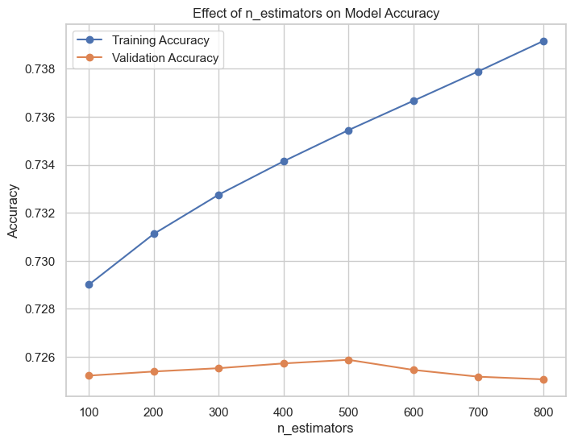

```python
# from xgboost import XGBClassifier
import matplotlib.pyplot as plt

# List of values for n_estimators to test
n_estimators_list = [100, 200, 300, 400,500,600, 700, 800]

# Empty lists to store accuracies
train_accuracies = []
val_accuracies = []

for n_estimators in n_estimators_list:
    # Initialize the XGBoost classifier with the desired parameters
    xgb = XGBClassifier(n_estimators=n_estimators, max_depth =5, learning_rate=0.1,random_state=42)

    # Train the model on the training set
    xgb.fit(X_train_scaled, y_train)

    # Calculate and store training accuracy
    train_accuracy = xgb.score(X_train_scaled, y_train)
    train_accuracies.append(train_accuracy)

    # Calculate and store validation accuracy
    val_accuracy = xgb.score(X_val_scaled, y_val)
    val_accuracies.append(val_accuracy)

# Plotting the graph
plt.figure(figsize=(8, 6))
plt.plot(n_estimators_list, train_accuracies, label='Training Accuracy', marker='o')
plt.plot(n_estimators_list, val_accuracies, label='Validation Accuracy', marker='o')
plt.xlabel('n_estimators')
plt.ylabel('Accuracy')
plt.title('Effect of n_estimators on Model Accuracy')
plt.legend()
plt.grid(True)
# Save the displayed plot
plt.savefig("Effect(n_estimators).png", dpi=200, bbox_inches='tight')


plt.show()  # Display the plot
```

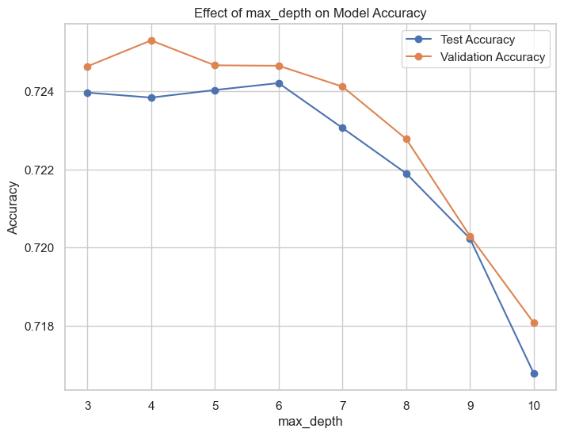

```python
from xgboost import XGBClassifier
import matplotlib.pyplot as plt

# List of values for max_depth to test
max_depth_list = [3, 4, 5, 6, 7, 8, 9, 10]

# Empty lists to store accuracies
test_accuracies = []
val_accuracies = []

for max_depth in max_depth_list:
    # Initialize the XGBoost classifier with the desired parameters
    xgb = XGBClassifier(max_depth=max_depth, random_state=42)

    # Train the model on the training set
    xgb.fit(X_train_scaled, y_train)

    # Calculate and store test set accuracy
    test_accuracy = xgb.score(X_test_scaled, y_test)
    test_accuracies.append(test_accuracy)

    # Calculate and store validation set accuracy
    val_accuracy = xgb.score(X_val_scaled, y_val)
    val_accuracies.append(val_accuracy)

# Plotting the graph
plt.figure(figsize=(8, 6))
plt.plot(max_depth_list, test_accuracies, label='Test Accuracy', marker='o')
plt.plot(max_depth_list, val_accuracies, label='Validation Accuracy', marker='o')
plt.xlabel('max_depth')
plt.ylabel('Accuracy')
plt.title('Effect of max_depth on Model Accuracy')
plt.legend()
plt.grid(True)
plt.savefig("Effect(max_depth).png", dpi=200,bbox_inches = 'tight')
plt.show()
```

After max_depth 6 the accuracy of both the test and validation accuracy went down.